**Instructor copy.** Executed notebook with all results shown, including the "after your attempt" cells. Projector/offline fallback; learners should use the notebook itself.

# f1 · One component, two phases: by hand and in code

**Learning question:** for one invented component A that can be SOLID or LIQUID, which phase is stable at a given temperature, and what may an optimiser change?

Used in: Day 1 W4–W6 and W8 (W5 is the demonstration), Lesson 1, self-study step 01. Work each "your turn" on paper first, then type your value. Labels such as (W4), (D1), (Lesson 5) or Clinic D point to the printed one-day primers (Day 1 and Day 2 worksheets) and the detailed lessons of the classroom course in the repository. Working alone on the website, you only need the step numbers.

**The plan.** f0 showed that at fixed T and p the equilibrium state has the lowest Gibbs energy G. Here that idea is used on the simplest possible case: one kind of atom that can be either solid or liquid. You will (1) write down each phase's Gibbs energy as a straight line in T, (2) compare the two lines at several temperatures, first by hand and then with NumPy, and (3) see what a computer "optimiser" is allowed to change when it looks for the minimum.

Run the setup cell first (see f0 for what it prints and for the `check` and `confirm` helpers).

```python
# Setup: run this cell first. Locally it finds the course folder; in Colab it
# downloads the tested course release and the locked package versions.
# In Colab, the first run then restarts the session on purpose and Colab reports
# a crash: that is expected. Run this cell again, then the rest of the notebook.
RELEASE = "main"
import os, pathlib, subprocess, sys, time
ROOT = next((p for p in (pathlib.Path.cwd(), *pathlib.Path.cwd().parents)
             if (p / "pyproject.toml").is_file() and (p / "course").is_dir()), None)
if ROOT is None and "google.colab" in sys.modules:
    ROOT = pathlib.Path("/content/CalphadIntro")
    if not ROOT.is_dir():
        clone = ["git", "clone", "-q", "--depth", "1", "--branch", RELEASE,
                 "https://github.com/ukerzel/CalphadIntro.git", str(ROOT)]
        git = dict(os.environ, GIT_TERMINAL_PROMPT="0")
        if subprocess.run(clone, env=git, capture_output=True).returncode:
            raise SystemExit(f"Could not download course release {RELEASE}: check the internet "
                             "connection and run this cell again.")
    if not (ROOT / ".colab-ready").exists():
        if subprocess.run([sys.executable, "-m", "pip", "install", "-q", "-r",
                           str(ROOT / "notebooks" / "requirements-colab.txt")]).returncode:
            raise SystemExit("Installing the course packages failed; run this cell again.")
        (ROOT / ".colab-ready").touch()
        # Colab has already loaded its own numpy; a fresh session is needed to use the installed versions.
        print("Installed the course's package versions. Colab now restarts this session and"
              " reports a crash; that is expected. When it has reconnected, run this cell again"
              " (it will not install twice), then the rest of the notebook.", flush=True)
        time.sleep(3)
        os.kill(os.getpid(), 9)
if ROOT is None:
    raise SystemExit("Open this notebook from the course folder (poetry run jupyter lab) or in Colab.")
os.chdir(ROOT)
sys.path.insert(0, str(ROOT))
from notebooks.helpers import check, confirm, database, show_versions
show_versions(RELEASE)
```

```
Course release main · Python 3.12.14
  numpy       2.5.3
  scipy       1.18.1
  matplotlib  3.11.2
  xarray      2026.7.0
  pycalphad   0.11.2
```

```
True
```

## 1. The whole model (W4)

Closed bulk sample, one mole of A atoms, p = 100000 Pa, 800–1200 K, only SOLID and LIQUID. A is invented, not a real element. With constant h and s in each phase, g = h − Ts:

| Phase | h (J/mol) | s (J/(mol K)) | g (J/mol) |
| --- | --- | --- | --- |
| SOLID | 1000 | 10 | 1000 − 10T |
| LIQUID | 7000 | 16 | 7000 − 16T |

**Reading the table.** Lower-case letters are *molar* quantities, per mole of atoms: h is the molar enthalpy (J/mol), s the molar entropy (J/(mol K)) and g = h − Ts the molar Gibbs energy (J/mol). The words in the setup matter: *closed* means no atoms enter or leave, *bulk* means the sample is large enough that surfaces do not matter.

The numbers make physical sense. The LIQUID has the higher h, because melting breaks bonds and that costs energy (here 7000 − 1000 = 6000 J/mol, the heat of melting). The LIQUID also has the higher s, because its atoms are more disordered. Each g is a straight line in T: it starts at h when T = 0 and falls with slope −s. The LIQUID line starts higher but falls faster, so at some temperature the two lines cross. Below the crossing one phase has the lower g; above it, the other.

**The Python.** `def g_solid(T):` defines a *function*: a named recipe that takes an input T and `return`s a result. The indented line is the body of the function. Calling `g_solid(900)` runs the recipe with T = 900.

```python
def g_solid(T):
    return 1000.0 - 10.0 * T   # J/mol, T in K  (h = 1000 J/mol, s = 10 J/(mol K))

def g_liquid(T):
    return 7000.0 - 16.0 * T   # J/mol  (h = 7000 J/mol, s = 16 J/(mol K))

# Call both functions at 900 K and print the results with 0 decimals.
print(f"900 K: g_SOLID = {g_solid(900):.0f} J/mol, g_LIQUID = {g_liquid(900):.0f} J/mol")
```

```
900 K: g_SOLID = -8000 J/mol, g_LIQUID = -7400 J/mol
```

**What to look at.** Both energies are negative, and the *lower* (more negative) one belongs to the phase that is stable at 900 K. A negative Gibbs energy is normal: only differences between Gibbs energies have a physical meaning.

### Your turn

Fill the 1000 K and 1100 K rows, then solve 1000 − 10T = 7000 − 16T for the crossing temperature (K).

To solve the equation, collect the T terms on one side and the numbers on the other. You may type the arithmetic itself as your answer.

```python
g_solid_1000 = None   # J/mol
g_liquid_1100 = None  # J/mol
T_crossing = None     # K
check(g_solid_1000, "f1_gs_1000")
check(g_liquid_1100, "f1_gl_1100")
check(T_crossing, "f1_crossing")
```

```
f1_gs_1000: not attempted yet. Replace None with your value and run the cell again.
f1_gl_1100: not attempted yet. Replace None with your value and run the cell again.
f1_crossing: not attempted yet. Replace None with your value and run the cell again.
```

## 2. The same arithmetic as a code cell (W5)

This is the Lesson 1 cell, unchanged. The constants 1000, 10, 7000 and 16 are the **model**; the temperatures are the **question** we ask it.

Instead of calling a function once per temperature, the cell puts all five temperatures into one NumPy array and computes every row of the table at once.

- `np.array([...])` turns a Python list of numbers into an array.
- `1000.0 - 10.0 * temperatures` acts on each element: the result is again an array of five numbers, one g_SOLID per temperature.
- `np.minimum(solid, liquid)` compares the two arrays element by element and keeps the smaller value at each position: the lowest Gibbs energy at each T.
- `np.column_stack([...])` places the four arrays side by side as the columns of a table, so the printout has one row per temperature: T, g_SOLID, g_LIQUID and the lower of the two (all in J/mol).

```python
import numpy as np

temperatures = np.array([800.0, 900.0, 1000.0, 1100.0, 1200.0])   # K, the question
solid = 1000.0 - 10.0 * temperatures       # J/mol, one value per temperature
liquid = 7000.0 - 16.0 * temperatures      # J/mol
lowest = np.minimum(solid, liquid)         # J/mol, the smaller of the two at each T
print(np.column_stack([temperatures, solid, liquid, lowest]))   # columns: T, SOLID, LIQUID, lowest
```

```
[[   800.  -7000.  -5800.  -7000.]
 [   900.  -8000.  -7400.  -8000.]
 [  1000.  -9000.  -9000.  -9000.]
 [  1100. -10000. -10600. -10600.]
 [  1200. -11000. -12200. -12200.]]
```

**What to look at.** Compare the last column with the two before it: in each row it equals one of them. The phase whose value it copies is the stable phase at that temperature. Watch where the choice switches from one column to the other.

### Your turn

Predict both energies at 950 K on paper, then change the temperatures in the cell above to check. Enter your predictions here.

(To change the temperatures, edit the numbers inside `np.array([...])` above, for example add `950.0` to the list, and run that cell again with Shift+Enter.)

```python
g_solid_950 = None   # J/mol
g_liquid_950 = None  # J/mol
check(g_solid_950, "f1_gs_950")
check(g_liquid_950, "f1_gl_950")
```

```
f1_gs_950: not attempted yet. Replace None with your value and run the cell again.
f1_gl_950: not attempted yet. Replace None with your value and run the cell again.
```

## 3. What may an optimiser change? (W6)

Let f_L be the liquid fraction and f_S = 1 − f_L, both between 0 and 1. At fixed T and p the optimiser minimises $g_{mix} = (1 - f_L)\,g_S + f_L\,g_L$. It may change the fractions, never the model. The cell below shows the idea at 1100 K; your turn is at 900 K.

**Where the formula comes from.** Our one mole of atoms may split into two portions: f_L mol in the LIQUID and f_S = 1 − f_L mol in the SOLID. Each portion contributes its amount times its molar Gibbs energy, so the total is the weighted average above. ("mix" here means a mixture of two phases side by side, not atoms mixed within one phase.) The two fractions must add up to 1 because no atoms are created or lost, and neither may be negative because a phase cannot hold a negative amount of atoms.

Note the division of roles. The *model* (the lines g_S and g_L) is fixed input. The *fractions* are the only thing the optimiser is allowed to vary. An optimiser that changed the model to lower the energy would be answering a different question.

**The Python.** `g_mix` calls the two functions from section 1. The expression `[g_mix(1100, f) for f in (0, 0.5, 1)]` is a *list comprehension*: it evaluates `g_mix(1100, f)` for f = 0, then 0.5, then 1, and collects the three results in a list.

```python
def g_mix(T, f_liquid):
    return (1 - f_liquid) * g_solid(T) + f_liquid * g_liquid(T)   # J/mol, weighted by the phase fractions

print("f_L:", [0, 0.5, 1], "→ g_mix(1100 K) =", [g_mix(1100, f) for f in (0, 0.5, 1)], "J/mol")
```

```
f_L: [0, 0.5, 1] → g_mix(1100 K) = [-10000.0, -10300.0, -10600.0] J/mol
```

**What to look at.** How does g_mix change as f_L goes from 0 to 0.5 to 1? Is the change steady (equal steps) or curved? Use that observation in your turn.

### Your turn

What is g_mix at 900 K for f_L = 0.25? And which f_L minimises it? At f_L = −0.2 the formula gives a lower number; why must that be rejected?

```python
g_mix_quarter = None  # J/mol
best_f_liquid = None
check(g_mix_quarter, "f1_gmix_025")
check(best_f_liquid, "f1_best_fl_900")
```

```
f1_gmix_025: not attempted yet. Replace None with your value and run the cell again.
f1_best_fl_900: not attempted yet. Replace None with your value and run the cell again.
```

## After your attempt: the optimiser and the plots

The course code solves the same problem with SciPy's `linprog`: variables [f_S, f_L], objective [g_S, g_L], balance f_S + f_L = 1, bounds 0…1.

**What `linprog` does.** SciPy is a package of scientific routines; `linprog` solves a *linear programme*: find the unknowns that make a weighted sum as small as possible, while some linear equations hold and each unknown stays within bounds. Here:

- the unknowns are the fractions f_S and f_L;
- the quantity to minimise is f_S g_S + f_L g_L, so the weights are the two Gibbs energies at the chosen temperature;
- the one equation is f_S + f_L = 1 (one mole of atoms in total);
- the bounds are 0 ≤ f_S ≤ 1 and 0 ≤ f_L ≤ 1.

The course function `unary.equilibrium_at(T)` sets this up and returns a *dictionary* (a lookup table of named entries): `result["GM"]` is the minimum molar Gibbs energy in J/mol, and `result["fractions"]` is another dictionary mapping each phase name to its fraction. `.items()` walks through its name/value pairs.

The plotting part draws two panels side by side:

- Left: the two Gibbs lines against T (divided by 1000 to show kJ/mol), with the lower of the two drawn as a thick, faint line underneath.
- Right: g_mix at 900 K against f_L, including values of f_L outside 0…1. The line `inside = (f >= 0) & (f <= 1)` makes an array of True/False values, True where f is allowed; `f[inside]` keeps only the allowed points and `f[~inside]` (`~` means "not") the forbidden ones, which are drawn as crosses.

```
900 K: GM = -8000 J/mol, fractions {'SOLID': 1.0, 'LIQUID': 0.0}
✓ Minimum at 900 K reproduces the lesson value.
✓ Crossing temperature reproduces the lesson value.
```

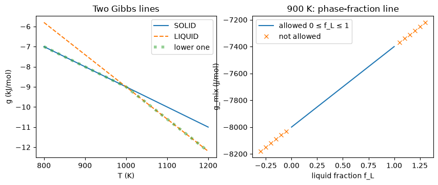

```python
#@title After your attempt: run to check with the course code and plot
from course.foundations import one_component_manual as unary   # the course's plain-Python version of this model
import matplotlib.pyplot as plt

result = unary.equilibrium_at(900.0)   # dictionary with "GM" (J/mol) and "fractions"
print(f"900 K: GM = {result['GM']:.0f} J/mol, fractions",
      {phase: round(amount, 9) + 0.0 for phase, amount in result["fractions"].items()})  # + 0.0 shows −0 as 0
confirm(result["GM"], -8000.0, "Minimum at 900 K", tol=1e-6)
confirm(unary.transition_temperature(), 1000.0, "Crossing temperature", tol=1e-8)

T = np.linspace(800, 1200, 81)   # K, 81 temperatures in steps of 5 K
fig, (left, right) = plt.subplots(1, 2, figsize=(10, 3.6))   # 1 row, 2 panels
left.plot(T, g_solid(T) / 1000, "-", label="SOLID")           # / 1000: J/mol → kJ/mol
left.plot(T, g_liquid(T) / 1000, "--", label="LIQUID")
left.plot(T, np.minimum(g_solid(T), g_liquid(T)) / 1000, ":", lw=4, alpha=0.5, label="lower one")   # lw: line width, alpha: transparency
left.set(xlabel="T (K)", ylabel="g (kJ/mol)", title="Two Gibbs lines")
left.legend()
f = np.linspace(-0.3, 1.3, 33)       # trial liquid fractions, some outside 0…1 on purpose
inside = (f >= 0) & (f <= 1)         # True where the fraction is physically allowed
right.plot(f[inside], g_mix(900, f[inside]), "-", label="allowed 0 ≤ f_L ≤ 1")
right.plot(f[~inside], g_mix(900, f[~inside]), "x", label="not allowed")   # ~ flips True and False
right.set(xlabel="liquid fraction f_L", ylabel="g_mix (J/mol)", title="900 K: phase-fraction line")
right.legend()
plt.show()
```

### At the crossing: does the solver's choice matter?

At exactly 1000 K the two lines cross, so every split has the same energy (W6: a tie gives a segment). Two of SciPy's methods, the dual simplex (`"highs-ds"`) and the interior-point method (`"highs-ipm"`), may then return different fractions. The cell asks both and checks what still matters: the energy and the balance. Which fractions they return is something to look at, not to assume.

```python
from scipy.optimize import linprog   # the linear-programme solver used by the course code

for method in ("highs-ds", "highs-ipm"):
    r = linprog([g_solid(1000), g_liquid(1000)], A_eq=[[1, 1]], b_eq=[1], bounds=[(0, 1), (0, 1)], method=method)
    print(f"{method:9s}: f_S = {r.x[0]:.3f}, f_L = {r.x[1]:.3f}, g_mix = {r.fun:.1f} J/mol")
    assert abs(r.fun - g_mix(1000, 0.5)) < 1e-9, "at the crossing every split must have the same energy"
    assert abs(r.x.sum() - 1) < 1e-12, "the fractions must add up to 1"
```

```
highs-ds : f_S = 0.000, f_L = 1.000, g_mix = -9000.0 J/mol
highs-ipm: f_S = 0.000, f_L = 1.000, g_mix = -9000.0 J/mol
```

Both answers are right: any f_L between 0 and 1 gives the same g_mix at the crossing, so a solver may report either end or anything between. What a reader must check is the energy and the balance, never the particular split. The advanced steps read this same problem with many candidate states instead of two.

## 4. Consolidate and catch an error (W8)

At **1050 K**: compute both energies, decide which phase is lower and give the minimum energy. Then correct two fictional reports:

- A: at 900 K, "g_S = −8 J/mol, g_L = −7.4 kJ/mol, so solid wins." Give the correct g_S in J/mol.
- B: at 900 K, "f_S = 0.8 and f_L = 0.4 satisfy the one-mole balance." Give the reported sum f_S + f_L, and say whether the report satisfies the one-mole balance (`True` or `False`).

For the last answer type the Python word `True` or `False` (capital first letter, no quotes).

```python
g_solid_1050 = None   # J/mol
g_liquid_1050 = None  # J/mol
minimum_1050 = None   # J/mol
g_solid_report_a = None    # the correct value in J/mol
sum_report_b = None        # f_S + f_L as reported
balanced_report_b = None   # True or False
check(g_solid_1050, "f1_gs_1050")
check(g_liquid_1050, "f1_gl_1050")
check(minimum_1050, "f1_min_1050")
check(g_solid_report_a, "f1_report_a")
check(sum_report_b, "f1_report_b_sum")
check(balanced_report_b, "f1_report_b_balanced")
```

```
f1_gs_1050: not attempted yet. Replace None with your value and run the cell again.
f1_gl_1050: not attempted yet. Replace None with your value and run the cell again.
f1_min_1050: not attempted yet. Replace None with your value and run the cell again.
f1_report_a: not attempted yet. Replace None with your value and run the cell again.
f1_report_b_sum: not attempted yet. Replace None with your value and run the cell again.
f1_report_b_balanced: not attempted yet. Replace None with your value and run the cell again.
```

### More practice (self-study step 01)

At 975 K, which phase is lower?

```python
g_solid_975 = None   # J/mol
g_liquid_975 = None  # J/mol
check(g_solid_975, "f1_gs_975")
check(g_liquid_975, "f1_gl_975")
```

```
f1_gs_975: not attempted yet. Replace None with your value and run the cell again.
f1_gl_975: not attempted yet. Replace None with your value and run the cell again.
```

**Limits.** Invented lines with zero heat capacity, no pressure dependence and no interfaces; they predict nothing about a real element. At exactly 1000 K every balanced split has the same energy, so the fractions are not determined. Next: f2 · the same model in pycalphad.